# Reproducible Research, Peer Assignment #1

## Activity Monitoring Data Analysis, A Quick Look

### Synopsis

This report both describes the activity monitoring data collected by devices, as well as fulfills the Peer Assignment #1 course requirement. Devices from companies such as Garmin, Samsung, Jawbone and others are entering mainstream market use.<sup>[1](http://www.cnet.com/topics/wearable-tech/best-wearable-tech/)</sup> Large amounts of data are being collected and can be analysed more easily with available computing software and hardware. Unfortunately, as described in the assignment, there is “…a lack of statistical methods and software for processing and interpreting the data.”<sup>[2](https://class.coursera.org/repdata-011/human_grading/view/courses/973512/assessments/3/submissions)</sup>

The source of the data is identified as “a personal activity monitoring device.” For purposes of the assignment, we believe the data are intact and accurately reflect the output from such a monitoring device. The data were collected at 5 minute intervals during the months of October and Novermber 2012.

### Loading and Preprocessing the Data

The data contains 3 columns in a comma-delimited file. The file was included in a non-password protected zip file named “repdata-data-activity.zip.” We read in the data using the standard read.csv command, converting NA to true missing and date to a true date.

Basic description of the data follows:

```r
df <- read.csv("./data/activity.csv", na.strings="NA")
df$date.value <- as.Date(df$date, "%Y-%m-%d")
df$dow <- as.factor(weekdays(df$date.value))
str(df)
```

```
## 'data.frame':    17568 obs. of  5 variables:
##  $ steps     : int  NA NA NA NA NA NA NA NA NA NA ...
##  $ date      : Factor w/ 61 levels "2012-10-01","2012-10-02",..: 1 1 1 1 1 1 1 1 1 1 ...
##  $ interval  : int  0 5 10 15 20 25 30 35 40 45 ...
##  $ date.value: Date, format: "2012-10-01" "2012-10-01" ...
##  $ dow       : Factor w/ 7 levels "Friday","Monday",..: 2 2 2 2 2 2 2 2 2 2 ...
```

```r
summary(df)
```

```
##      steps                date          interval        date.value
##  Min.   :  0.00   2012-10-01:  288   Min.   :   0.0   Min.   :2012-10-01
##  1st Qu.:  0.00   2012-10-02:  288   1st Qu.: 588.8   1st Qu.:2012-10-16
##  Median :  0.00   2012-10-03:  288   Median :1177.5   Median :2012-10-31
##  Mean   : 37.38   2012-10-04:  288   Mean   :1177.5   Mean   :2012-10-31
##  3rd Qu.: 12.00   2012-10-05:  288   3rd Qu.:1766.2   3rd Qu.:2012-11-15
##  Max.   :806.00   2012-10-06:  288   Max.   :2355.0   Max.   :2012-11-30
##  NA's   :2304     (Other)   :15840
##         dow
##  Friday   :2592
##  Monday   :2592
##  Saturday :2304
##  Sunday   :2304
##  Thursday :2592
##  Tuesday  :2592
##  Wednesday:2592
```

Missing values in steps account for 13.11% of the observations.

### Per Day Calculations

We calculated the mean and median steps per day, ignoring missing values, and produced the following histogram.

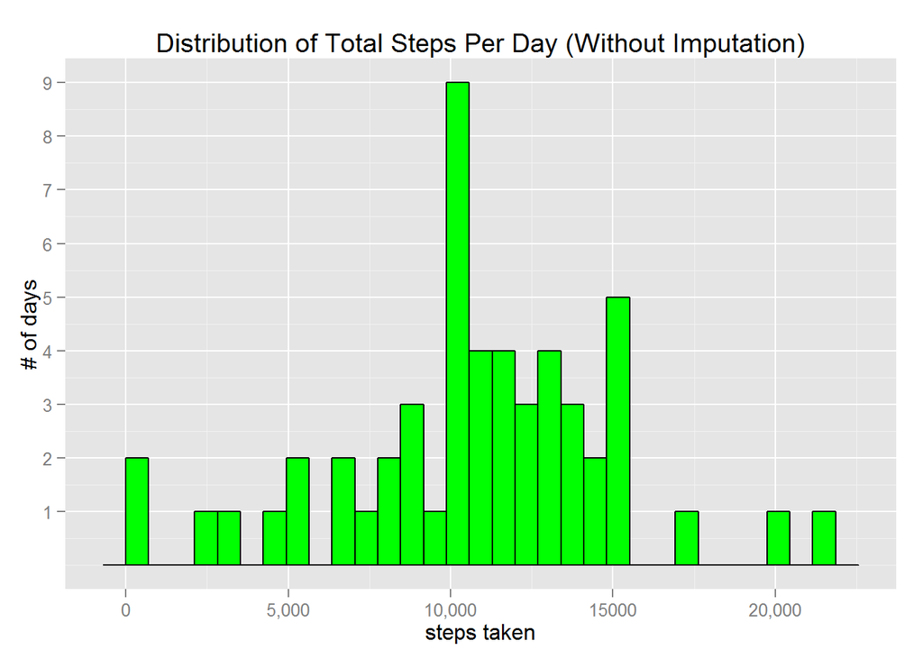

### Average Daily Activity Patterns

We calculated the mean number of steps per 5 minute interval and produced the following graphic.

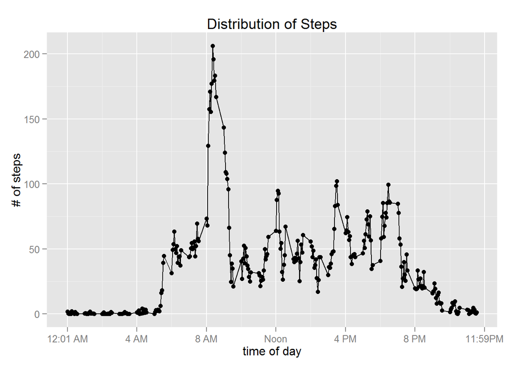

### Computing Missing Values

As discussed in the assignment, missing values can sometimes lead to bias in calculations. AS reported earlier, missing values account for 13.11% (2,304) of the possible 17,568 step observations.

We imputed missing steps using a transform function from Ken Kleinsman in “Example 2014.5: Simple mean imputation.”<sup>[3](http://www.r-bloggers.com/example-2014-5-simple-mean-imputation/)</sup>

```r
df.imputed  = transform(df, steps = ifelse(is.na(steps), mean(steps, na.rm=TRUE), steps))
```

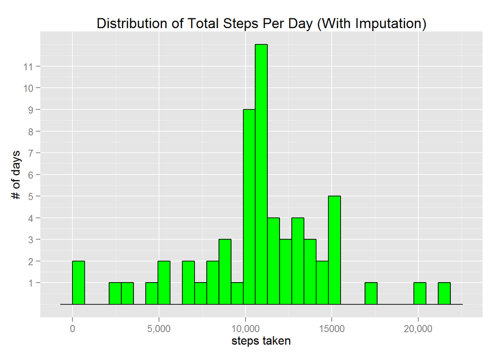

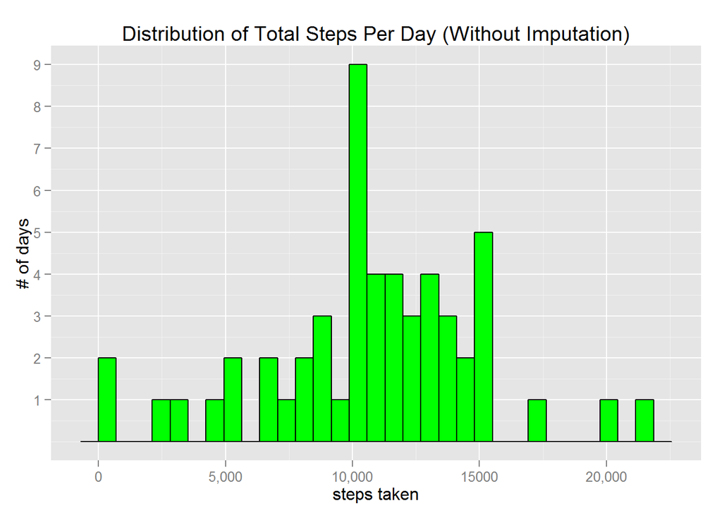

```r
summary(perday$steps)
```

```
##    Min. 1st Qu.  Median    Mean 3rd Qu.    Max.
##      42    8842   10770   10770   13300   21200
```

```r
summary(perday.imputed$steps)
```

```
##    Min. 1st Qu.  Median    Mean 3rd Qu.    Max.
##      42    9820   10770   10770   12810   21200
```

### Differences Between Weekdays and Weekends

In order to compare differences in activity between weekdays (Monday through Friday) and weekends (Saturday and Sunday), we constructed a factor using a slick piece of code from Yingua, Hu on nabble.com.<sup>[4](http://r.789695.n4.nabble.com/Summing-daily-values-by-weekday-and-weekend-td3685732.html)</sup> This creates a factor variable for our new plots.

```r
df.imputed$period <- as.factor(ifelse(weekdays( df.imputed$date.value) %in% c("Saturday","Sunday"), "Weekend", "Weekday"))

table(df.imputed$dow,df.imputed$period)
```

```
##
##             Weekday Weekend
##   Friday       2592       0
##   Monday       2592       0
##   Saturday        0    2304
##   Sunday          0    2304
##   Thursday     2592       0
##   Tuesday      2592       0
##   Wednesday    2592       0
```

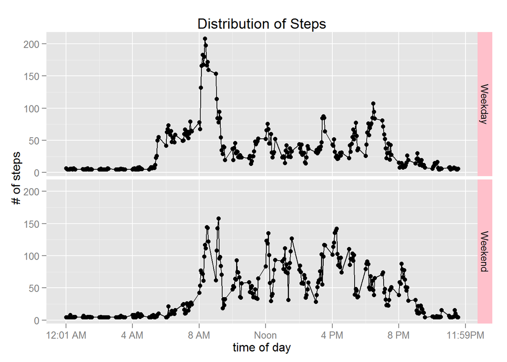

### Libraries Loaded

The following libraries are needed for reproducing the output: *knitr, dplyr, ggplot2, stats, graphics, grDevices, utils, datasets, methods, base*

This run was created with R version 3.1.2 (2014-10-31) on a windows x64 bit machine.